# Autodifferentiation Engine from Scratch

- Show All Code
- Hide All Code
- View Source

## Introduction

**This project implements a reverse-mode automatic differentiation library from scratch** — no PyTorch, no TensorFlow, no ML framework of any kind. The only dependency is NumPy.

The library centers on a `BearTensor` abstraction: a wrapper around NumPy arrays that records every arithmetic operation performed on it, building a dynamic computation graph in the forward pass. When `.backward()` is called on a loss node, the engine traverses that graph in reverse topological order and propagates gradients all the way back to every leaf parameter — exactly the mechanism that powers gradient descent in modern deep learning frameworks.

## Setup

```python
from __future__ import annotations
import numpy as np
from dataclasses import dataclass
import matplotlib.pyplot as plt
from collections import deque
from copy import deepcopy
import warnings
warnings.filterwarnings('ignore')

np.random.seed(189)
```

## The BearTensor Abstraction

**The core data structure is `BearTensor`**, a thin wrapper around a NumPy array that adds three things: a human-readable name (useful for graph visualization), a list of parent nodes in the computation graph, and an `adjoint` field that accumulates the gradient during the backward pass.

Two supporting dataclasses make this work. `BearGrad` stores a callable `fn` that, given the upstream gradient, computes the gradient to pass downstream — it applies the chain rule at one edge of the graph. `BearParent` pairs a `BearTensor` with its `BearGrad`, so each node knows both *who* its parents are and *how* to send them their gradients.

```python
@dataclass
class BearGrad:
    fn: callable
    op_str: str | None = None

@dataclass
class BearParent:
    parent: 'BearTensor'
    grad: BearGrad

    def __hash__(self):
        return id(self)

    def __eq__(self, other):
        return self is other

class BearTensor:
    def __init__(self, name: str, value: np.ndarray, parents: list | None = None):
        self.name = name
        self.value = value
        self.parents = parents if parents is not None else []
        self.adjoint: float | np.ndarray = 0.0
```

## Building the Computation Graph

**Every arithmetic operation on a `BearTensor` returns a new tensor whose parent list records where it came from.** This is operator overloading — Python calls `__add__`, `__mul__`, etc. whenever you write `a + b` on these objects. Each operation simultaneously computes the forward value *and* registers the backward gradient function, capturing the operand values as closures so backprop knows what derivatives to apply later.

This is what makes the graph *dynamic*: it is built anew on every forward pass, so loops and conditionals in the forward code are handled naturally without any special tracing or compilation step.

```python
def __add__(self, other):
    if self.value.shape != other.value.shape:
        raise ValueError("Shapes must match")
    return BearTensor(f"({self.name}+{other.name})", self.value + other.value, [
        BearParent(self,  BearGrad(lambda g: g)),
        BearParent(other, BearGrad(lambda g: g)),
    ])

def __sub__(self, other):
    if self.value.shape != other.value.shape:
        raise ValueError("Shapes must match")
    return BearTensor(f"({self.name}-{other.name})", self.value - other.value, [
        BearParent(self,  BearGrad(lambda g: g)),
        BearParent(other, BearGrad(lambda g: -g)),
    ])

def __mul__(self, other):
    if self.value.shape != other.value.shape:
        raise ValueError("Shapes must match")
    sv, ov = self.value, other.value
    return BearTensor(f"({self.name}*{other.name})", sv * ov, [
        BearParent(self,  BearGrad(lambda g: g * ov)),
        BearParent(other, BearGrad(lambda g: g * sv)),
    ])

def __pow__(self, power: float):
    sv = self.value
    return BearTensor(f"({self.name}**{power})", sv ** power, [
        BearParent(self, BearGrad(lambda g: g * power * sv ** (power - 1))),
    ])

def __matmul__(self, other):
    sv, ov = self.value, other.value
    s0, s1 = sv.shape, ov.shape
    result = np.atleast_1d(sv @ ov)

    def grad_sv(g):
        if ov.ndim == 1:
            return np.outer(g, ov).reshape(s0)
        return (np.atleast_2d(g) @ ov.T).reshape(s0)

    def grad_ov(g):
        if sv.ndim == 1:
            return np.outer(sv, g).reshape(s1)
        return (np.atleast_2d(sv).T @ np.atleast_2d(g)).reshape(s1)

    return BearTensor(f"({self.name}@{other.name})", result, [
        BearParent(self,  BearGrad(grad_sv)),
        BearParent(other, BearGrad(grad_ov)),
    ])

def dot(self, other):
    if self.value.ndim != 1 or other.value.ndim != 1:
        raise ValueError("dot() only supports 1-D BearTensors.")
    sv, ov = self.value, other.value
    return BearTensor(f"dot({self.name},{other.name})", np.atleast_1d(np.dot(sv, ov)), [
        BearParent(self,  BearGrad(lambda g: np.squeeze(g) * ov)),
        BearParent(other, BearGrad(lambda g: np.squeeze(g) * sv)),
    ])

def sum(self):
    sv = self.value
    return BearTensor(f"sum({self.name})", np.atleast_1d(np.sum(sv)), [
        BearParent(self, BearGrad(lambda g: np.squeeze(g) * np.ones_like(sv))),
    ])

def mean(self):
    sv = self.value
    n = sv.size
    return BearTensor(f"mean({self.name})", np.atleast_1d(np.mean(sv)), [
        BearParent(self, BearGrad(lambda g: np.squeeze(g) * np.ones_like(sv) / n)),
    ])

def relu(self):
    sv = self.value
    return BearTensor(f"relu({self.name})", np.maximum(0, sv), [
        BearParent(self, BearGrad(lambda g: g * (sv > 0))),
    ])

def sigmoid(self):
    sv = self.value
    sig = 1.0 / (1.0 + np.exp(-sv))
    return BearTensor(f"sigmoid({self.name})", sig, [
        BearParent(self, BearGrad(lambda g: g * sig * (1 - sig))),
    ])

BearTensor.__add__    = __add__
BearTensor.__sub__    = __sub__
BearTensor.__mul__    = __mul__
BearTensor.__pow__    = __pow__
BearTensor.__matmul__ = __matmul__
BearTensor.dot        = dot
BearTensor.sum        = sum
BearTensor.mean       = mean
BearTensor.relu       = relu
BearTensor.sigmoid    = sigmoid
```

## Visualizing Computation Graphs

**To make the computation graph tangible, I built a visualization utility** using the [Fletcher](https://typst.app/universe/package/fletcher) Typst package. After any forward pass, `draw_graph(root)` traverses the graph, assigns nodes to levels via BFS, applies a barycentric crossing-minimization heuristic to reduce edge crossings, then emits a Typst source file that compiles to a PDF.

```python
from utils import draw_graph

a = BearTensor("a", np.array([2, 3]))
b = BearTensor("b", np.array([1, 1]))
c = a + b
draw_graph(c, "demo_graph.typ")
```

The rendered graph for `c = a + b`:

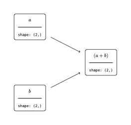

Computation graph for `c = a + b`, rendered via the Typst/Fletcher backend.

## Backpropagation via Topological Sort

**The backward pass works in two steps.** First, a topological sort of the computation graph determines a valid propagation order — every node must receive all incoming gradients before it can pass gradients onward. Second, we traverse the sorted list in reverse and accumulate adjoints via the chain rule.

The sort uses an iterative DFS to avoid Python’s call-stack limit on deep networks. A node is appended to the output list only *after* all its descendants have been processed, so reversing the list gives root-first order — exactly what backprop needs.

```python
def topological_sort(node):
    visited = set()
    sorted_nodes = []
    stack = [(node, False)]
    while stack:
        n, processed = stack.pop()
        if processed:
            sorted_nodes.append(n)
            continue
        if n in visited:
            continue
        visited.add(n)
        stack.append((n, True))
        for p in n.parents:
            if p.parent not in visited:
                stack.append((p.parent, False))
    return sorted_nodes

def reset_children(self):
    for node in topological_sort(self):
        node.adjoint = 0.0

def backward(self):
    self.reset_children()
    self.adjoint = 1.0
    for node in reversed(topological_sort(self)):
        for bp in node.parents:
            bp.parent.adjoint += bp.grad.fn(node.adjoint)

BearTensor.reset_children = reset_children
BearTensor.backward = backward
```

**Note**

Setting the root node’s adjoint to 1.0 before the loop is the base case of the chain rule: $\partial L / \partial L = 1$. Every other adjoint is then accumulated by repeatedly applying each edge’s stored gradient function.

## Optimizers

**With gradients computed, an optimizer updates the parameters.** All three share a base class that holds the parameter list and exposes `zero_grad()` to clear adjoints between training steps.

### SGD

The simplest update rule — subtract the gradient scaled by the learning rate. No memory of past gradients.

```python
class Optimizer:
    def __init__(self, params: list, lr: float):
        self.params = params
        self.lr = lr

    def zero_grad(self):
        for p in self.params:
            p.adjoint = np.zeros_like(p.value)

    def step(self):
        raise NotImplementedError

class SGD(Optimizer):
    def step(self):
        for p in self.params:
            p.value -= self.lr * p.adjoint
```

### Momentum

**Momentum accumulates a velocity vector** that smooths out gradient noise. At each step the velocity decays by `beta` and is nudged in the gradient direction, allowing the optimizer to accelerate through consistent gradient directions and dampen oscillations across inconsistent ones.

```python
class Momentum(Optimizer):
    def __init__(self, params, lr, beta=0.9):
        super().__init__(params, lr)
        self.beta = beta
        self.velocities = [np.zeros_like(p.value) for p in self.params]

    def step(self):
        for i, p in enumerate(self.params):
            self.velocities[i] = self.beta * self.velocities[i] - self.lr * p.adjoint
            p.value += self.velocities[i]
```

### Adam

**Adam maintains per-parameter adaptive learning rates** by tracking both the first moment (mean of past gradients) and the second moment (uncentered variance). Bias correction in early steps prevents the moment estimates from being pulled toward zero before they have had time to warm up.

```python
class Adam(Optimizer):
    def __init__(self, params, lr, beta1=0.9, beta2=0.999, eps=1e-8):
        super().__init__(params, lr)
        self.beta1 = beta1
        self.beta2 = beta2
        self.eps = eps
        self.t = 0
        self.ms = [np.zeros_like(p.value) for p in self.params]
        self.vs = [np.zeros_like(p.value) for p in self.params]

    def step(self):
        self.t += 1
        for i, p in enumerate(self.params):
            self.ms[i] = self.beta1 * self.ms[i] + (1 - self.beta1) * p.adjoint
            self.vs[i] = self.beta2 * self.vs[i] + (1 - self.beta2) * p.adjoint ** 2
            m_hat = self.ms[i] / (1 - self.beta1 ** self.t)
            v_hat = self.vs[i] / (1 - self.beta2 ** self.t)
            p.value -= self.lr * m_hat / (np.sqrt(v_hat) + self.eps)
```

## Optimizer Convergence Comparison

**To compare the optimizers empirically**, I trained a 3-layer network (24→12→12→1 with sigmoid activations) on 1,000 random samples for 100 steps, starting from identical initial weights for each optimizer.

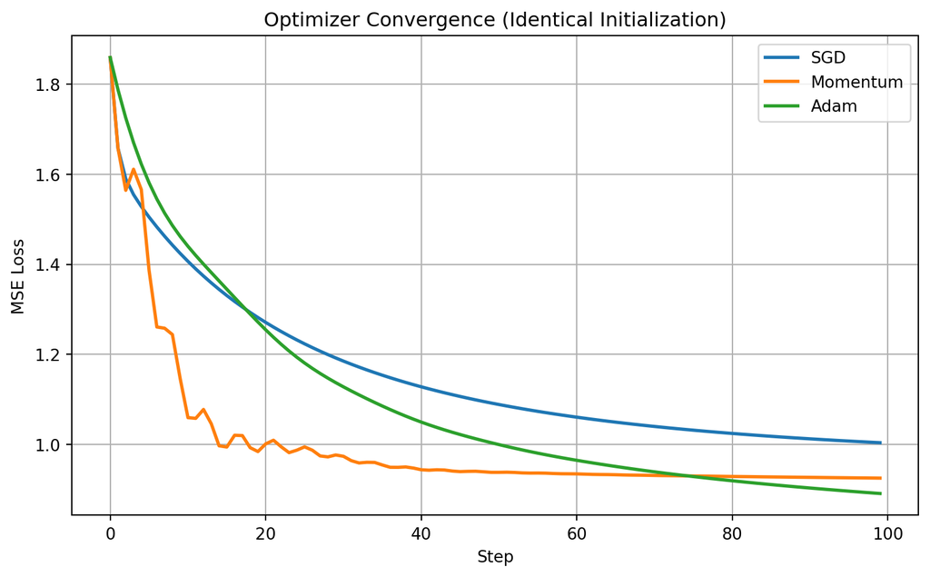

```python
def compare_optimizers(optimizers, n_steps=100):
    np.random.seed(0)
    X = BearTensor("X", np.random.randn(1000, 24))
    y = BearTensor("y", np.random.randn(1000, 1))

    W1_init = np.random.randn(24, 12)
    W2_init = np.random.randn(12, 12)
    W3_init = np.random.randn(12, 1)

    results = {}
    for opt_class, title, lr in optimizers:
        W1 = BearTensor("W1", deepcopy(W1_init))
        W2 = BearTensor("W2", deepcopy(W2_init))
        W3 = BearTensor("W3", deepcopy(W3_init))
        optimizer = opt_class([W1, W2, W3], lr=lr)
        losses = []
        for _ in range(n_steps):
            optimizer.zero_grad()
            h1 = (X @ W1).sigmoid()
            h2 = (h1 @ W2).sigmoid()
            output = h2 @ W3
            loss = ((output - y) ** 2).mean()
            loss.backward()
            losses.append(loss.value.item())
            optimizer.step()
        results[title] = losses
    return results

results = compare_optimizers([
    (SGD,      "SGD",      0.05),
    (Momentum, "Momentum", 0.05),
    (Adam,     "Adam",     0.005),
])

plt.figure(figsize=(8, 5))
for title, losses in results.items():
    plt.plot(losses, label=title, linewidth=2)
plt.xlabel("Step")
plt.ylabel("MSE Loss")
plt.title("Optimizer Convergence (Identical Initialization)")
plt.legend()
plt.grid(True)
plt.tight_layout()
plt.show()
```

## Training on Wine Quality

**To validate the engine end-to-end**, I used it to train a two-layer MLP on the [Wine Quality dataset](https://archive.ics.uci.edu/dataset/186/wine+quality) — 1,599 red wine samples, each described by 11 physicochemical features (acidity, sulfates, alcohol content, etc.), with the task of predicting a quality score on a 0–10 scale.

The architecture is a single hidden layer of 16 units with sigmoid activations, followed by a linear output node. I trained with Adam for 200 epochs, with standard scaling applied to the input features beforehand.

```python
from sklearn.datasets import fetch_openml
from sklearn.preprocessing import StandardScaler
from sklearn.model_selection import train_test_split

data = fetch_openml("wine-quality-red", as_frame=True)
X_raw = data.data.to_numpy()
y_raw = data.target.to_numpy().astype(float)

scaler = StandardScaler()
X_scaled = scaler.fit_transform(X_raw)

X_train, X_test, y_train, y_test = train_test_split(
    X_scaled, y_raw, test_size=0.4, random_state=42, shuffle=True
)

X_tensor = BearTensor("X_train", X_train)
y_tensor = BearTensor("y_train", y_train.reshape(-1, 1))

np.random.seed(42)
W1 = BearTensor("W1", np.random.randn(11, 16) * 0.1)
W2 = BearTensor("W2", np.random.randn(16, 1) * 0.1)

optimizer = Adam([W1, W2], lr=0.01)
train_losses = []

for epoch in range(200):
    optimizer.zero_grad()
    h = (X_tensor @ W1).sigmoid()
    output = h @ W2
    loss = ((output - y_tensor) ** 2).mean()
    loss.backward()
    optimizer.step()
    train_losses.append(loss.value.item())
```

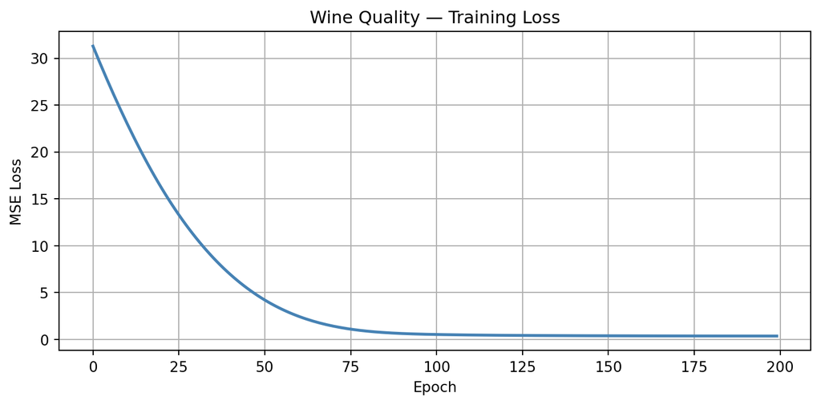

Training loss decreases smoothly and consistently across all 200 epochs, confirming the correctness of the autodiff engine, optimizer, and training loop.

```python
plt.figure(figsize=(8, 4))
plt.plot(train_losses, linewidth=2, color='steelblue')
plt.xlabel("Epoch")
plt.ylabel("MSE Loss")
plt.title("Wine Quality — Training Loss")
plt.grid(True)
plt.tight_layout()
plt.show()
```

```python
def predict(x: np.ndarray) -> float:
    """Return a quality score prediction for a single scaled feature vector."""
    x_t = BearTensor("x", x.reshape(1, -1))
    h = (x_t @ W1).sigmoid()
    return (h @ W2).value.item()

X_test_t = BearTensor("X_test", X_test)
h_test = (X_test_t @ W1).sigmoid()
out_test = h_test @ W2
test_mse = np.mean((out_test.value.flatten() - y_test) ** 2)

# Baseline: always predict the mean training-set quality score
baseline_mse = np.mean((y_train.mean() - y_test) ** 2)

print(f"Final training MSE : {train_losses[-1]:.4f}")
print(f"Test MSE           : {test_mse:.4f}")
print(f"Mean-baseline MSE  : {baseline_mse:.4f}")
print(f"Reduction vs. mean : {1 - test_mse / baseline_mse:.1%}")
```

```
Final training MSE : 0.3580
Test MSE           : 0.4093
Mean-baseline MSE  : 0.6503
Reduction vs. mean : 37.1%
```

**Important**

Loss decreased smoothly across all 200 epochs. The network reaches a test MSE of 0.41, compared with 0.65 for a baseline that always predicts the mean training-set quality score, a 37% reduction. This confirms that the full pipeline — dynamic graph construction, topological-sort backprop, Adam optimizer, and training loop — works correctly, built entirely on NumPy with no ML framework.

## The Muon Optimizer

**Muon is a gradient optimizer that replaces raw momentum with an *orthogonalized* update**, motivated by a subtle flaw in standard momentum. A gradient matrix $G = U\Sigma V^\top$ has a singular value decomposition where a few large singular values can dominate the update, leaving directions with small singular values largely ignored. Standard momentum preserves this imbalance.

Muon corrects this by approximating $UV^\top$ — the same singular vectors, but with all singular values set to 1, so every gradient direction gets an equal-weight update. This approach attracted attention by beating AdamW in the [NanoGPT speedrun benchmark](https://kellerjordan.github.io/posts/muon/).

**Computing the exact SVD at every step is prohibitively expensive**, so Muon uses Newton-Schulz iteration instead — a fast polynomial approximation that drives all singular values toward 1. Starting from $X_0 = G / \|G\|_F$, each iteration applies:

$$X \leftarrow 1.5\,X - 0.5\,(XX^\top)\,X$$

After a few steps this converges to a close approximation of $UV^\top$. The result is then rescaled by $\sqrt{\text{fan\_out}/\text{fan\_in}}$ to keep update magnitudes consistent across layers of different shapes.

```python
class Muon(Optimizer):
    def __init__(self, params, lr, momentum=0.95, eps=1e-7, ns_steps=5):
        super().__init__(params, lr)
        self.momentum = momentum
        self.eps = eps
        self.ns_steps = ns_steps
        self.buffers = [np.zeros_like(p.value, dtype=float) for p in self.params]

    def newton_schulz(self, G: np.ndarray) -> np.ndarray:
        """Approximate UV^T of G via Newton-Schulz iteration."""
        X = G.astype(float, copy=True)
        X /= (np.linalg.norm(X, 'fro') + self.eps)
        for _ in range(self.ns_steps):
            X = 1.5 * X - 0.5 * (X @ X.T) @ X
        return X

    def step(self):
        for i, p in enumerate(self.params):
            self.buffers[i] = self.momentum * self.buffers[i] + p.adjoint
            fan_out, fan_in = p.value.shape[0], p.value.shape[1]
            O = np.sqrt(fan_out / fan_in) * self.newton_schulz(self.buffers[i])
            p.value -= self.lr * O
```

**Comparing all four optimizers on the same convergence task:**

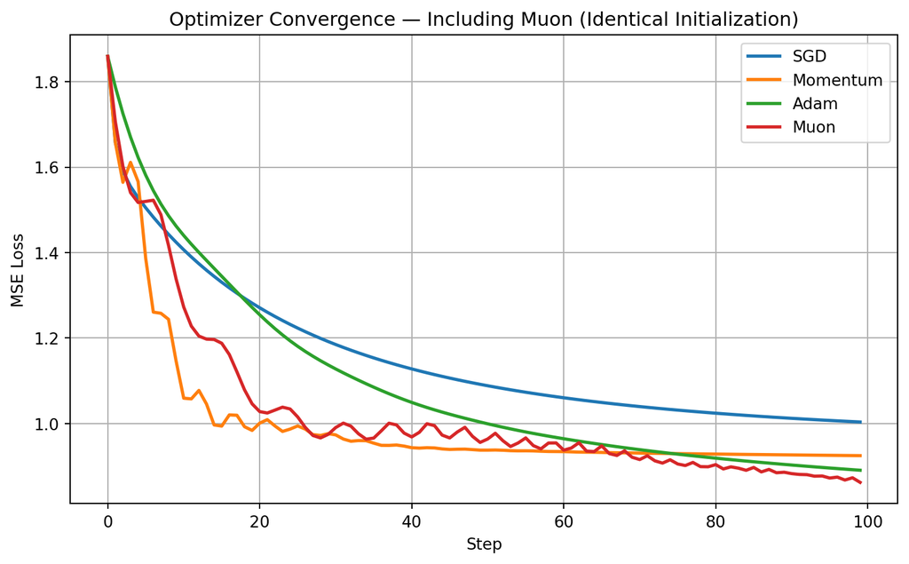

All four optimizers are compared from identical starting weights. Muon’s orthogonalized updates are most impactful at scale; on this small synthetic task, Adam remains competitive.

```python
results_muon = compare_optimizers([
    (SGD,      "SGD",      0.05),
    (Momentum, "Momentum", 0.05),
    (Adam,     "Adam",     0.005),
    (Muon,     "Muon",     0.02),
])

plt.figure(figsize=(8, 5))
for title, losses in results_muon.items():
    plt.plot(losses, label=title, linewidth=2)
plt.xlabel("Step")
plt.ylabel("MSE Loss")
plt.title("Optimizer Convergence — Including Muon (Identical Initialization)")
plt.legend()
plt.grid(True)
plt.tight_layout()
plt.show()
```

**Note**

Muon’s advantage over AdamW becomes most pronounced on large language model training with large batch sizes — the setting where the NanoGPT speedrun is measured. On this small synthetic regression task, where gradient noise is low and the network is shallow, Adam’s adaptive learning rates remain highly competitive.